# PSTAT131-HW6

Joshua Price

5/26/2022

**Exercise 1**  
Read in the data and set things up as in Homework 5:

-Use clean_names() -Filter out the rarer Pokémon types -Convert type_1 and legendary to factors Do an initial split of the data; you can choose the percentage for splitting. Stratify on the outcome variable.

Fold the training set using v-fold cross-validation, with v = 5. Stratify on the outcome variable.

Set up a recipe to predict type_1 with legendary, generation, sp_atk, attack, speed, defense, hp, and sp_def:

-Dummy-code legendary and generation; -Center and scale all predictors.

```r
library(janitor)
pokemon <- read.csv("Pokemon.csv")
pokemon_cn <- pokemon %>% clean_names()
set.seed(2505)

pokemon_f <- pokemon_cn %>% filter(type_1 == "Bug" | type_1 ==  "Fire" | type_1 == "Grass"| type_1 =="Normal"| type_1 =="Water"| type_1 =="Psychic")

pokemon_f$type_1 <- as.factor(pokemon_f$type_1)
pokemon_f$legendary <- as.factor(pokemon_f$legendary)
pokemon_f$generation <- as.factor(pokemon_f$generation)

pokemon_split <- initial_split(pokemon_f, prop=.7, strata = type_1)
pokemon_train <- training(pokemon_split)
pokemon_test <- testing(pokemon_split)

pokemon_folds <- vfold_cv(pokemon_train, v = 5, strata=type_1)

pokemon_recipe <- recipe(type_1 ~ legendary + generation + sp_atk + attack + speed + defense + hp + sp_def,data=pokemon_train) %>% step_dummy(c(legendary, generation)) %>% step_scale() %>% step_center()
```

**Exercise 2**  
Create a correlation matrix of the training set, using the corrplot package. Note: You can choose how to handle the continuous variables for this plot; justify your decision(s).

What relationships, if any, do you notice? Do these relationships make sense to you?  
-i only selected numeric between pokemon stats are numeric -there’s a high correlation between total and everything which makes sense because total is everything added up. -There;s also a higher correlation between sp def and def and atk with sp atk. These make sense because most pokemon specialize between one or the other.

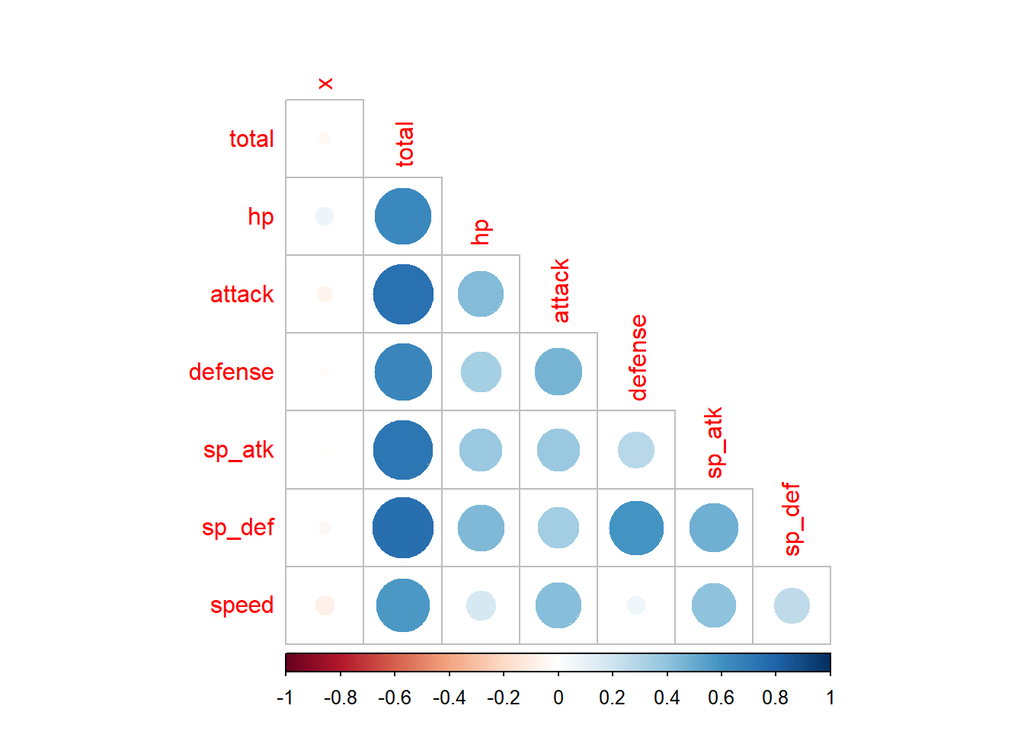

```r
pokemon_cor <- pokemon_train %>% select_if(is.numeric) %>% cor(use = "complete.obs") %>% corrplot(type = "lower", diag = FALSE)
```

**Exercise 3**  
First, set up a decision tree model and workflow. Tune the cost_complexity hyperparameter. Use the same levels we used in Lab 7 – that is, range = c(-3, -1). Specify that the metric we want to optimize is roc_auc.

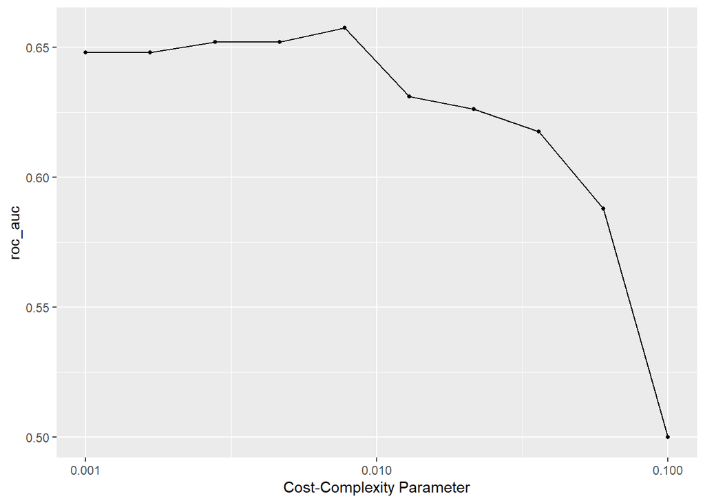

```r
tree_spec <-decision_tree() %>% set_engine("rpart")

class_tree_spec <- tree_spec %>% set_mode("classification")

class_tree_wf <- workflow() %>% add_model(class_tree_spec %>% set_args(cost_complexity = tune())) %>% add_recipe(pokemon_recipe)

param_grid <- grid_regular(cost_complexity(range = c(-3, -1)), levels = 10)

tune_res <- tune_grid(class_tree_wf, resamples = pokemon_folds, grid = param_grid, metrics = metric_set(roc_auc))
autoplot(tune_res)
```

**Exercise 4**  
What is the roc_auc of your best-performing pruned decision tree on the folds? Hint: Use collect_metrics() and arrange().

```r
tree_roc_auc <- collect_metrics(tune_res) %>% arrange(-mean)
tree_roc_auc
```

```
## # A tibble: 10 x 7
##    cost_complexity .metric .estimator  mean     n std_err .config
##              <dbl> <chr>   <chr>      <dbl> <int>   <dbl> <chr>
##  1         0.00774 roc_auc hand_till  0.657     5  0.0177 Preprocessor1_Model05
##  2         0.00278 roc_auc hand_till  0.652     5  0.0127 Preprocessor1_Model03
##  3         0.00464 roc_auc hand_till  0.652     5  0.0127 Preprocessor1_Model04
##  4         0.001   roc_auc hand_till  0.648     5  0.0129 Preprocessor1_Model01
##  5         0.00167 roc_auc hand_till  0.648     5  0.0129 Preprocessor1_Model02
##  6         0.0129  roc_auc hand_till  0.631     5  0.0213 Preprocessor1_Model06
##  7         0.0215  roc_auc hand_till  0.626     5  0.0257 Preprocessor1_Model07
##  8         0.0359  roc_auc hand_till  0.618     5  0.0266 Preprocessor1_Model08
##  9         0.0599  roc_auc hand_till  0.588     5  0.0155 Preprocessor1_Model09
## 10         0.1     roc_auc hand_till  0.5       5  0      Preprocessor1_Model10
```

**Exercise 5**  
Using rpart.plot, fit and visualize your best-performing pruned decision tree with the training set.

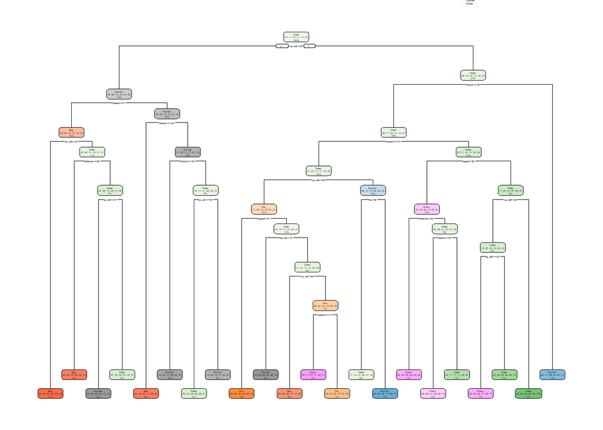

```r
best_complexity <- select_best(tune_res)
class_tree_final <- finalize_workflow(class_tree_wf, best_complexity)
class_tree_final_fit <- fit(class_tree_final, data = pokemon_train)

class_tree_final_fit %>% extract_fit_engine() %>% rpart.plot()
```

**Exercise 5**  
Now set up a random forest model and workflow. Use the ranger engine and set importance = “impurity”. Tune mtry, trees, and min_n. Using the documentation for rand_forest(), explain in your own words what each of these hyperparameters represent.

Create a regular grid with 8 levels each. You can choose plausible ranges for each hyperparameter. Note that mtry should not be smaller than 1 or larger than 8. Explain why not. What type of model would mtry = 8 represent?  
-mtry is the number of variables randomly sampled at each split -trees is the number of trees -min_n is the minimum number of points in one group for a zplit -We cant predict with 0 predictors and we cant predict with more predictors than we have thus it’s 1-8 -mtry = 8 would be a bagging model

```r
forest_spec <- rand_forest() %>% set_engine("ranger", importance = "impurity") %>% set_mode("classification")

forest_wf <- workflow() %>% add_model(forest_spec %>% set_args(mtry = tune(), trees = tune(), min_n = tune())) %>% add_recipe(pokemon_recipe)

multi_param_grid <- grid_regular(mtry(range = c(1,8)), trees(range(1,200)), min_n(range(1,30)), levels = 8)

multi_tune_res <- tune_grid(forest_wf, resamples = pokemon_folds, grid = multi_param_grid, metrics = metric_set(roc_auc) )
```

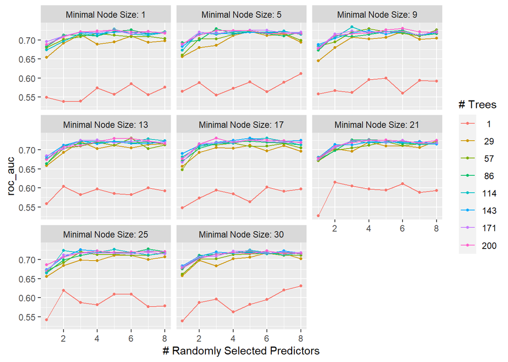

```r
autoplot(multi_tune_res)
```

**Exercise 7**  
What is the roc_auc of your best-performing random forest model on the folds? Hint: Use collect_metrics() and arrange().

```r
collect_metrics(multi_tune_res) %>% arrange(-mean)
```

```
## # A tibble: 512 x 9
##     mtry trees min_n .metric .estimator  mean     n std_err .config
##    <int> <int> <int> <chr>   <chr>      <dbl> <int>   <dbl> <chr>
##  1     3   114     9 roc_auc hand_till  0.734     5 0.00859 Preprocessor1_Model~
##  2     3   200    17 roc_auc hand_till  0.731     5 0.00928 Preprocessor1_Model~
##  3     5   143    17 roc_auc hand_till  0.731     5 0.0126  Preprocessor1_Model~
##  4     6    57    13 roc_auc hand_till  0.731     5 0.00987 Preprocessor1_Model~
##  5     6   200     9 roc_auc hand_till  0.730     5 0.0108  Preprocessor1_Model~
##  6     6   114    17 roc_auc hand_till  0.730     5 0.0125  Preprocessor1_Model~
##  7     5   200    13 roc_auc hand_till  0.730     5 0.0154  Preprocessor1_Model~
##  8     4    57     9 roc_auc hand_till  0.730     5 0.0154  Preprocessor1_Model~
##  9     6   200    13 roc_auc hand_till  0.730     5 0.00875 Preprocessor1_Model~
## 10     3    86     5 roc_auc hand_till  0.729     5 0.00690 Preprocessor1_Model~
## # ... with 502 more rows
```

```r
best_forest_model <- select_best(multi_tune_res, metric = "roc_auc")
```

**Exercise 8**  
Create a variable importance plot, using vip(), with your best-performing random forest model fit on the training set.

Which variables were most useful? Which were least useful? Are these results what you expected, or not?  
- the most useful variable were the stats of the pokemon and the least useful were the generation they’re from

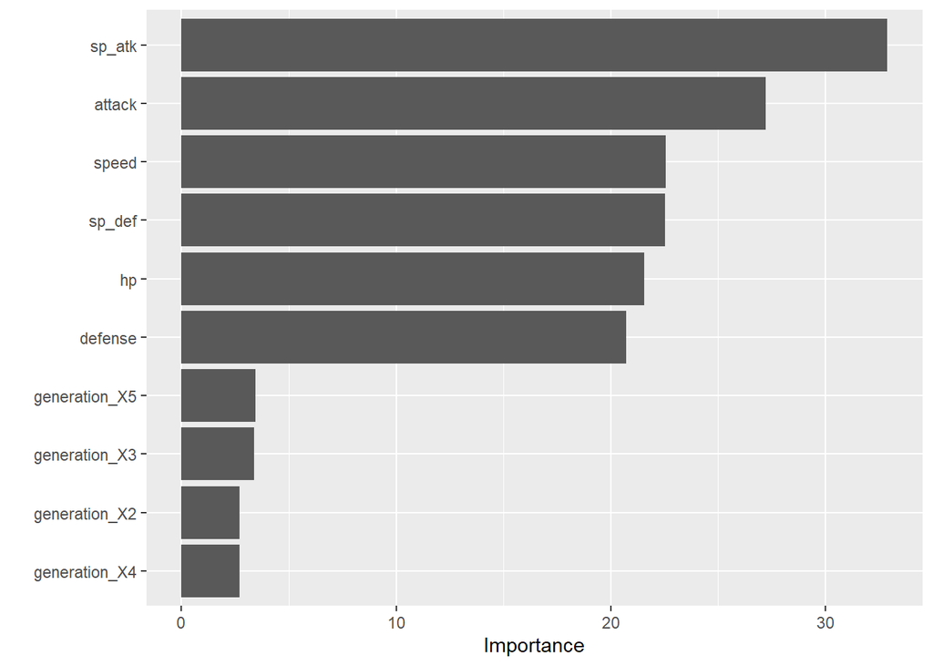

```r
best_model_final <- finalize_workflow(forest_wf, best_forest_model)
best_model_final_fit <- fit(best_model_final, data = pokemon_train)
best_model_final_fit %>% extract_fit_engine() %>% vip()
```

**Exercise 9**  
Finally, set up a boosted tree model and workflow. Use the xgboost engine. Tune trees. Create a regular grid with 10 levels; let trees range from 10 to 2000. Specify roc_auc and again print an autoplot() of the results.

What do you observe?

What is the roc_auc of your best-performing boosted tree model on the folds? Hint: Use collect_metrics() and arrange(). - 10 trees roc_auc has the lowest value while 452 trees has the highest with .723

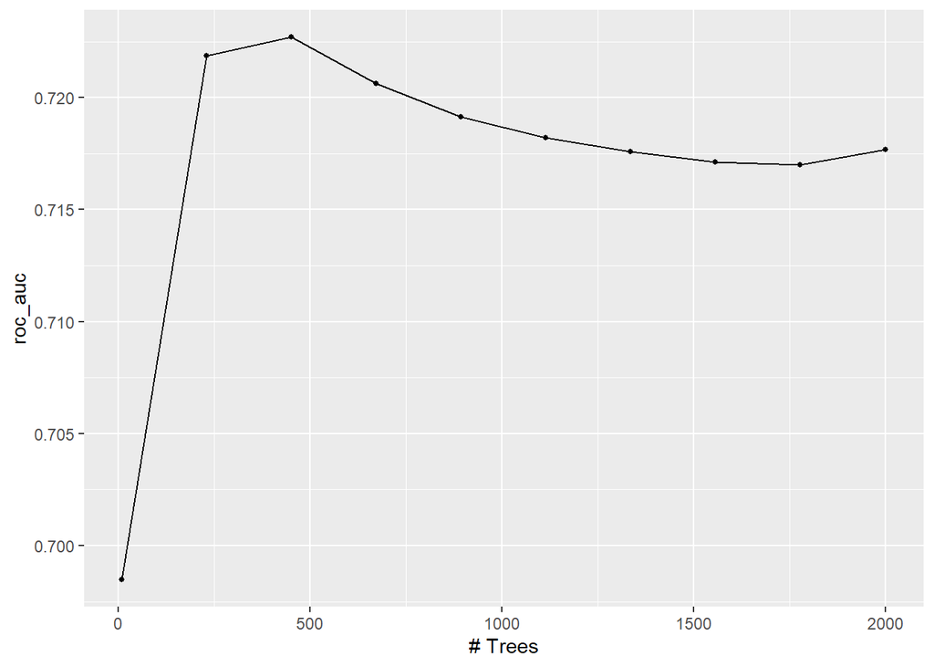

```r
boost_spec <- boost_tree() %>% set_engine("xgboost") %>% set_mode("classification")

boost_wf <- workflow() %>% add_model(boost_spec %>% set_args(trees = tune())) %>% add_recipe(pokemon_recipe)

boost_grid <- grid_regular(trees(range = c(10,2000)), levels = 10)

boost_tune_res <- tune_grid(boost_wf, resamples = pokemon_folds, grid = boost_grid, metrics = metric_set(roc_auc))

autoplot(boost_tune_res)
```

```r
collect_metrics(boost_tune_res) %>% arrange(-mean)
```

```
## # A tibble: 10 x 7
##    trees .metric .estimator  mean     n std_err .config
##    <int> <chr>   <chr>      <dbl> <int>   <dbl> <chr>
##  1   452 roc_auc hand_till  0.723     5  0.0130 Preprocessor1_Model03
##  2   231 roc_auc hand_till  0.722     5  0.0134 Preprocessor1_Model02
##  3   673 roc_auc hand_till  0.721     5  0.0142 Preprocessor1_Model04
##  4   894 roc_auc hand_till  0.719     5  0.0154 Preprocessor1_Model05
##  5  1115 roc_auc hand_till  0.718     5  0.0154 Preprocessor1_Model06
##  6  2000 roc_auc hand_till  0.718     5  0.0163 Preprocessor1_Model10
##  7  1336 roc_auc hand_till  0.718     5  0.0155 Preprocessor1_Model07
##  8  1557 roc_auc hand_till  0.717     5  0.0157 Preprocessor1_Model08
##  9  1778 roc_auc hand_till  0.717     5  0.0157 Preprocessor1_Model09
## 10    10 roc_auc hand_till  0.698     5  0.0159 Preprocessor1_Model01
```

```r
best_boost_final <- select_best(boost_tune_res)
best_boost_final_model <- finalize_workflow(boost_wf, best_boost_final)
best_boost_final_model_fit <- fit(best_boost_final_model, data = pokemon_train)
```

**Exercise 10**  
Display a table of the three ROC AUC values for your best-performing pruned tree, random forest, and boosted tree models. Which performed best on the folds? Select the best of the three and use select_best(), finalize_workflow(), and fit() to fit it to the testing set.

Print the AUC value of your best-performing model on the testing set. Print the ROC curves. Finally, create and visualize a confusion matrix heat map.

Which classes was your model most accurate at predicting? Which was it worst at?  
- my model was most accurate at predicting normal, then water and bug,

```r
pruned_roc_auc <- collect_metrics(tune_res) %>% arrange(-mean)
forest_roc_auc <- collect_metrics(multi_tune_res) %>% arrange(-mean)
boost_roc_auc <- collect_metrics(boost_tune_res) %>% arrange(-mean)

roc_auc_means <- c(pruned_roc_auc$mean[1], forest_roc_auc$mean[1], boost_roc_auc$mean[1])

Models <- c("Pruned Tree", "Random Forest", "Boosted Tree")
Total <- tibble(roc_auc = roc_auc_means, models = Models)
Total
```

```
## # A tibble: 3 x 2
##   roc_auc models
##     <dbl> <chr>
## 1   0.657 Pruned Tree
## 2   0.734 Random Forest
## 3   0.723 Boosted Tree
```

```r
#The random forest model performed the best between the three.

best_tree <- select_best(multi_tune_res)
best_tree_model <- finalize_workflow(forest_wf, best_forest_model)
best_tree_model_fit <- fit(best_tree_model, data = pokemon_test)

prediction <- augment(best_boost_final_model_fit, new_data = pokemon_test) %>% select(type_1, .pred_class, .pred_Bug,.pred_Fire, .pred_Grass, .pred_Normal, .pred_Psychic, .pred_Water)
accuracy(prediction, type_1, .pred_class)
```

```
## # A tibble: 1 x 3
##   .metric  .estimator .estimate
##   <chr>    <chr>          <dbl>
## 1 accuracy multiclass     0.321
```

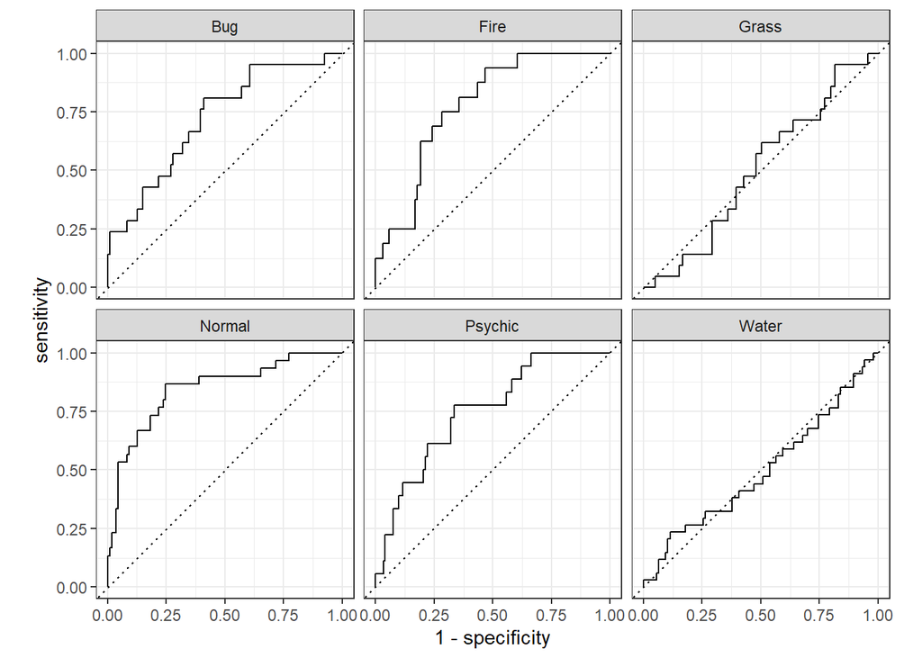

```r
prediction %>% roc_curve(type_1,.pred_Bug, .pred_Fire, .pred_Grass, .pred_Normal,.pred_Psychic, .pred_Water) %>% autoplot()
```

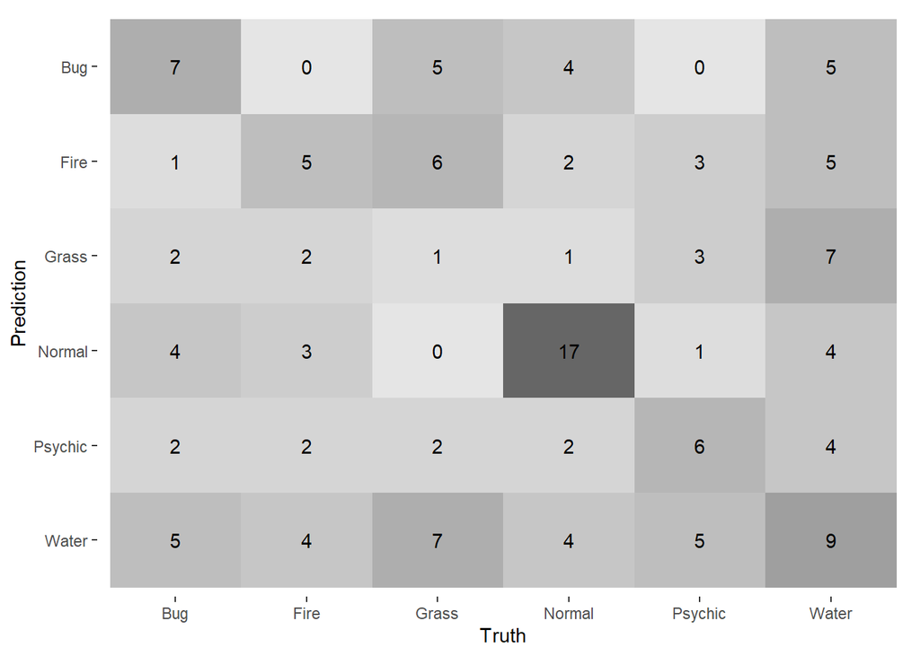

```r
prediction %>% conf_mat(type_1, .pred_class) %>% autoplot(type = "heatmap")
```